# Introduction to ggplot2

Elegant and versatile data visualisation in R

Rémi de Fleurian https://remidefleurian.com/ (QMUL)http://music-cognition.eecs.qmul.ac.uk/  
2020-07-03

## 1. Introduction

This workshop is based on [Chapter 3 - Data visualisation](https://r4ds.had.co.nz/data-visualisation.html), from the free online book [R for Data Science](https://r4ds.had.co.nz/).

ggplot2 is a data visualisation package based on the “tidyverse” approach to coding in R. In the tidyverse:

- functions are designed around [“tidy” data](https://r4ds.had.co.nz/tidy-data.html),
- always use a data frame as their first argument,
- and are chained together with `%>%` (pipe operator)

This workshop is presented in the form of an R notebook. From the `.Rmd` file, individual code chunks can be run, or a full `.html` output can be generated by clicking on the **Knit** button.

For this workshop, we need to load the tidyverse collection of packages.

```r
library(tidyverse)
```

## 2. Plotting

### 2.1. `mpg` data set

`mpg` is a practice data frame included with the ggplot2 package. Descriptions for each variable are available by typing `?mpg` in the console, and we can view the structure of the data frame with the `glimpse()` command.

```r
glimpse(mpg)
```

```
Rows: 234
Columns: 11
$ manufacturer <chr> "audi", "audi", "audi", "audi", "audi", "audi"…
$ model        <chr> "a4", "a4", "a4", "a4", "a4", "a4", "a4", "a4 …
$ displ        <dbl> 1.8, 1.8, 2.0, 2.0, 2.8, 2.8, 3.1, 1.8, 1.8, 2…
$ year         <int> 1999, 1999, 2008, 2008, 1999, 1999, 2008, 1999…
$ cyl          <int> 4, 4, 4, 4, 6, 6, 6, 4, 4, 4, 4, 6, 6, 6, 6, 6…
$ trans        <chr> "auto(l5)", "manual(m5)", "manual(m6)", "auto(…
$ drv          <chr> "f", "f", "f", "f", "f", "f", "f", "4", "4", "…
$ cty          <int> 18, 21, 20, 21, 16, 18, 18, 18, 16, 20, 19, 15…
$ hwy          <int> 29, 29, 31, 30, 26, 26, 27, 26, 25, 28, 27, 25…
$ fl           <chr> "p", "p", "p", "p", "p", "p", "p", "p", "p", "…
$ class        <chr> "compact", "compact", "compact", "compact", "c…
```

### 2.2. Basics

```r
ggplot(data = mpg) +
  geom_point(mapping = aes(x = displ, y = hwy))
```

[output not shown]

Each plot begins with the `ggplot()` function, which creates a blank canvas for the contents of the plot. `ggplot()` takes a data frame as the `data` argument, from which the plot will be generated.

`geom_point()` is one of many `geom_***()` functions, and indicates which type of layer should be added to the blank canvas. When used in a 2D canvas, `geom_point()` produces a scatter plot. Other popular geoms are `geom_line()`, `geom_bar()`, `geom_histogram()`, `geom_boxplot()`, or `geom_density()`. Options are listed in the [ggplot2 reference](https://ggplot2.tidyverse.org/reference/#section-geoms). Associated packages which extend the functionality of ggplot2 are listed in the [ggplot2 gallery](https://exts.ggplot2.tidyverse.org/gallery/).

The `mapping` argument defines which variables from the data frame should be mapped to the layer. It is always followed by the `aes()` function, in which mappings are defined.

Mappings can also be defined in the top-level `ggplot()` function rather than individually for each layer, in which case they carry over to each subsequent layer. Since the arguments `data`, `mapping`, `x`, and `y` are expected in most plots, they are generally not explicitly stated. A popular way to generate plots therefore makes use of the following syntax, which produces an identical plot to the one above (see [ggplot2 style guide](https://style.tidyverse.org/ggplot2.html)). This provides the opportunity to perform multiple operations on a data frame first, before piping it to the `ggplot()` function without needing to assign it first.

```r
mpg %>%
  ggplot(aes(displ, hwy)) +
  geom_point()
```

[output not shown]

### 2.3. Aesthetics

The `x` and `y` arguments are called aesthetics. There are many more available aesthetics, to indicate that additional variables should be taken into consideration. Popular aesthetics include `colour`, `fill`, `alpha`, `shape`, or `size`, and a full list is available with the `ggplot2:::.all_aesthetics` command. If additional aesthetics are specified, a legend is automatically created.

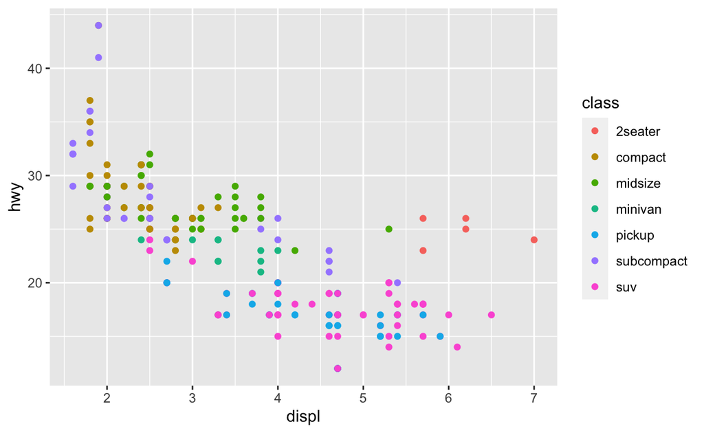

```r
mpg %>%
  ggplot(aes(displ, hwy, colour = class)) +
  geom_point()
```

Aesthetics can also be set manually, if specified outside of the `aes()` function. This is useful for fine-grained customisation of more complex plots.

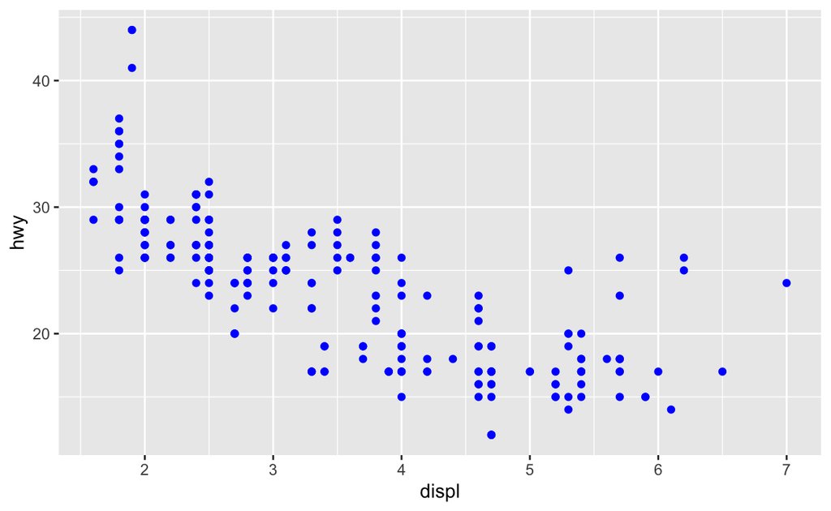

```r
mpg %>%
  ggplot(aes(displ, hwy)) +
  geom_point(colour = "blue")
```

### 2.4. Layers

Layers can be stacked to represent different visual properties of the data. For instance, `geom_smooth()` adds a smoothed line to your plot. As always, you can use `?geom_smooth` to get more information about the arguments of each function. Here, for instance, we can use different smoothing methods, by passing `lm`, `glm`, `loess`, or other values to the `method` argument.

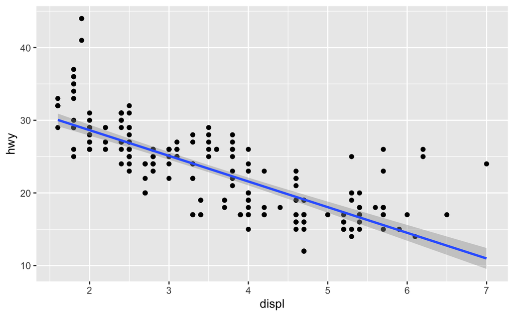

```r
mpg %>%
  ggplot(aes(displ, hwy)) +
  geom_point() +
  geom_smooth(method = "lm")
```

Aesthetics can be distributed as needed across the `ggplot()` function and the following geoms.

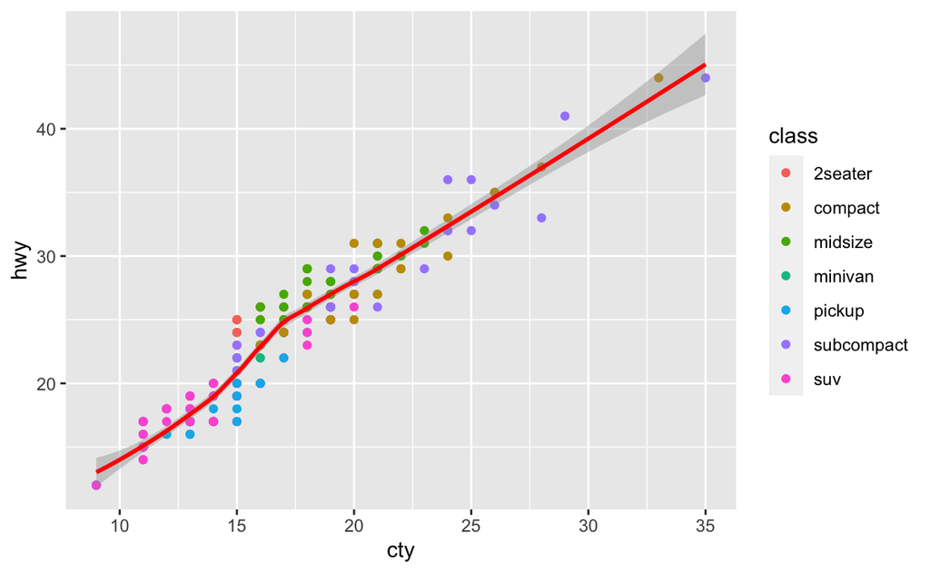

```r
mpg %>%
  ggplot(aes(cty, hwy)) +
  geom_point(aes(colour = class)) +
  geom_smooth(colour = "red")
```

### 2.5. Layout

Sometimes, for plots involving categorical data, it makes sense swap the x and y axes, to display horizontal columns or boxplots, or to provide more space for the labels on the x axis.

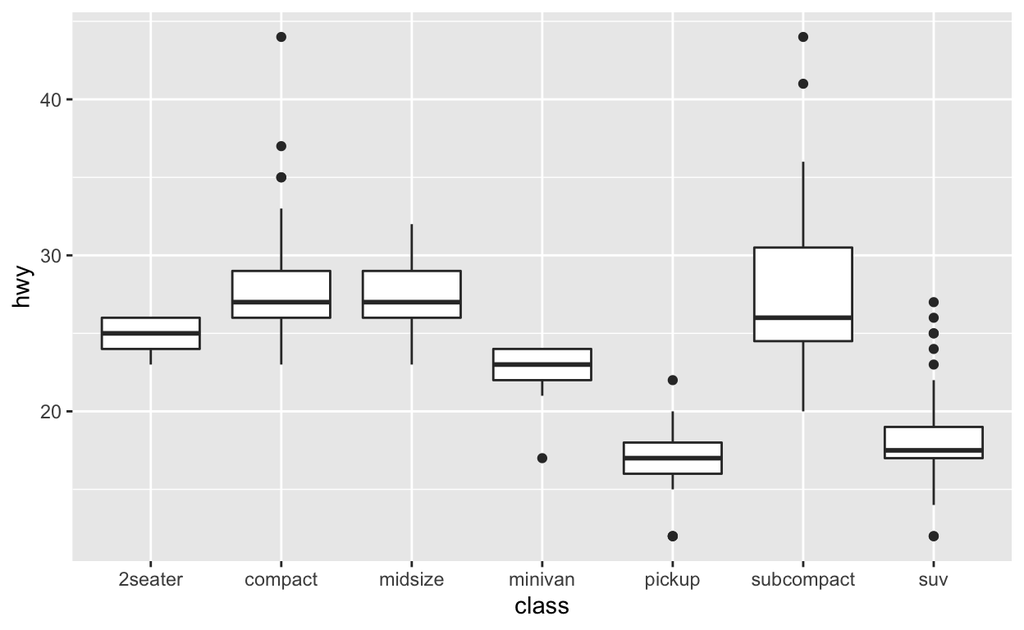

```r
# Before
mpg %>%
  ggplot(aes(class, hwy)) +
  geom_boxplot()
```

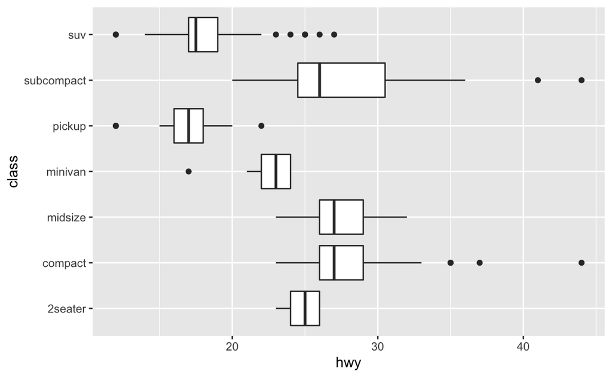

```r
# After
mpg %>%
  ggplot(aes(class, hwy)) +
  geom_boxplot() +
  coord_flip()
```

Plots can also be split into subplots according to values for one category, with `facet_wrap()`, or for two categories, with `facet_grid()`.

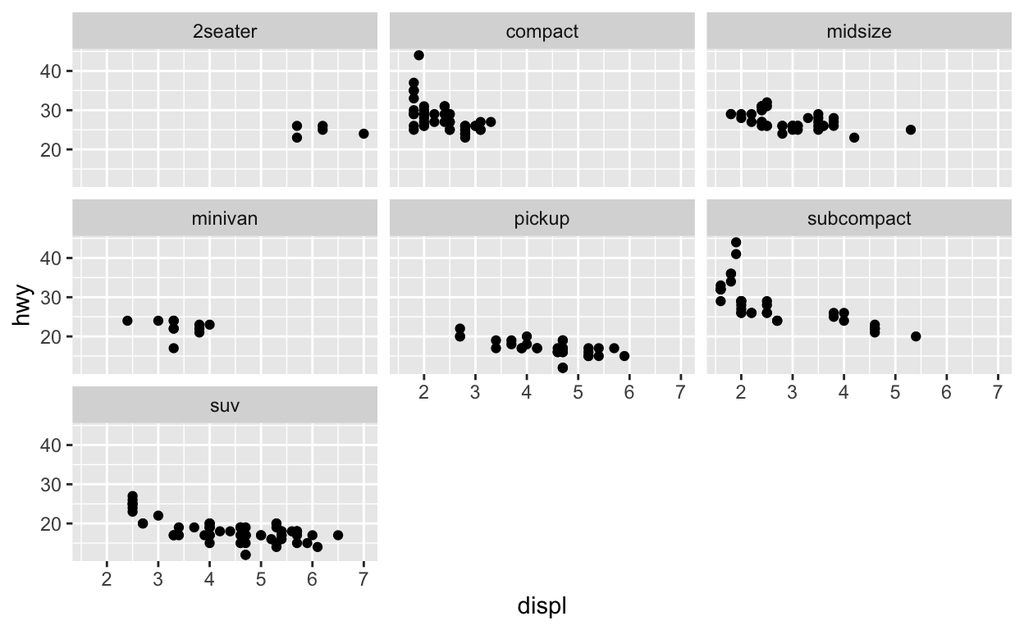

```r
mpg %>%
  ggplot(aes(displ, hwy)) +
  geom_point() +
  facet_wrap(~ class)
```

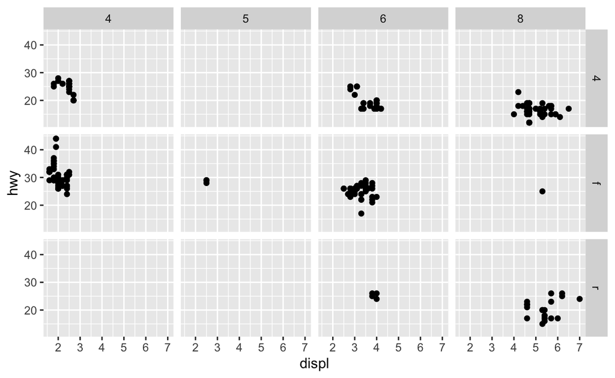

```r
mpg %>%
  ggplot(aes(displ, hwy)) +
  geom_point() +
  facet_grid(drv ~ cyl)
```

### 2.6. Customisation

Virtually everything can be customised on plots produced with ggplot2. A number of themes are available (see [ggplot2 reference](https://ggplot2.tidyverse.org/reference/#section-themes)), and many additional themes are available in associated packages (e.g., [`theme_apa()`](https://rdrr.io/cran/jtools/man/theme_apa.html) in the `jtools` package).

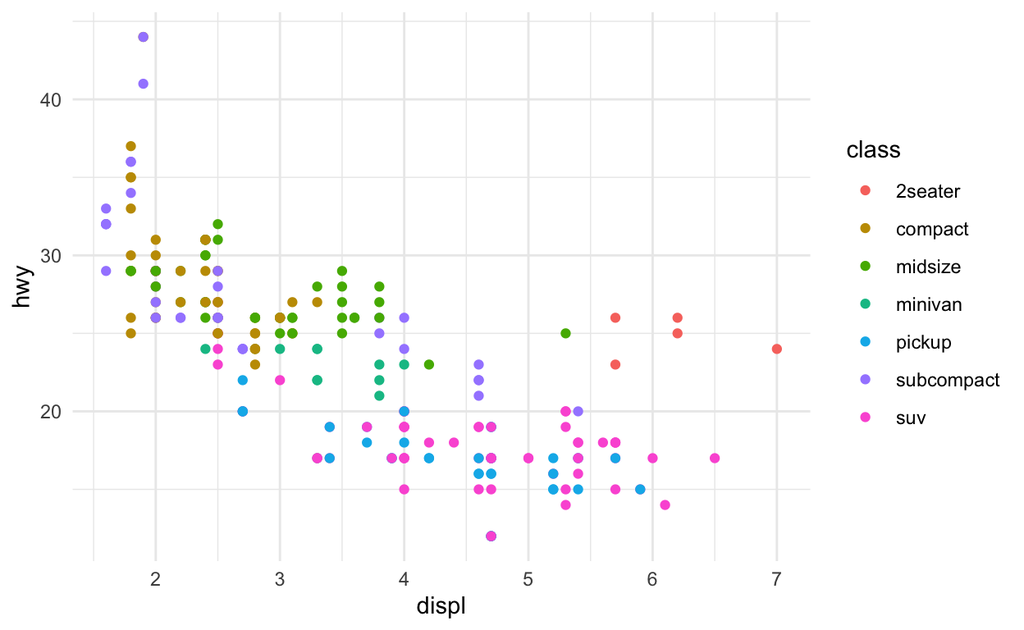

```r
mpg %>%
  ggplot(aes(displ, hwy, colour = class)) +
  geom_point() +
  theme_minimal()
```

Similarly, some colour palettes are included with ggpplot2, and many others are available in associated packages (see [`paletteer`](https://github.com/EmilHvitfeldt/paletteer) package for a convenient way to access palettes from many different packages). Colourblind-friendly palettes, such as `viridis` (see [vignette](https://cran.r-project.org/web/packages/viridis/vignettes/intro-to-viridis.html)), should be used for publication in academic journals. For more information on how to specify colour palettes, see [ggplot2 reference](https://ggplot2.tidyverse.org/reference/#section-scales).

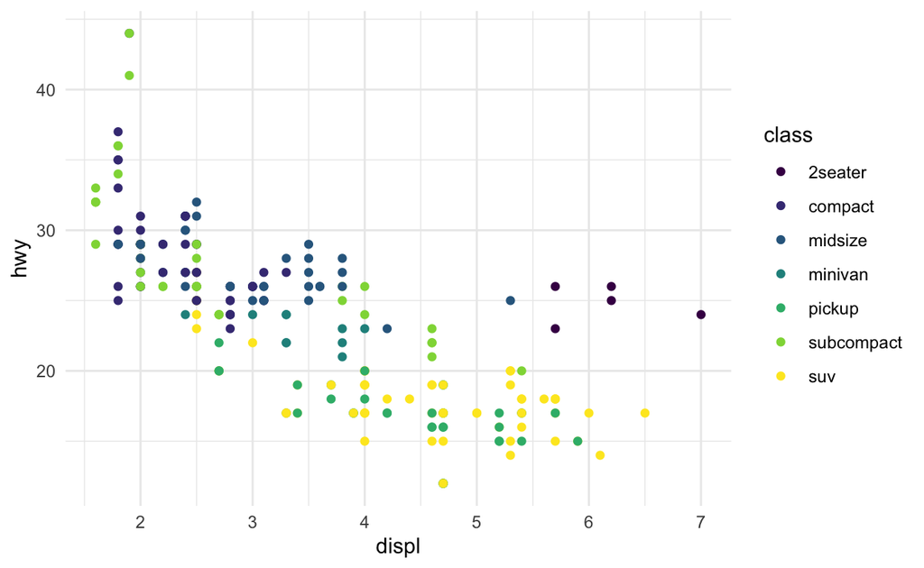

```r
mpg %>%
  ggplot(aes(displ, hwy, colour = class)) +
  geom_point() +
  theme_minimal() +
  scale_colour_viridis_d()
```

There are many ways to specify titles, depending on what is needed exactly. A convenient way is to use the `labs()` function.

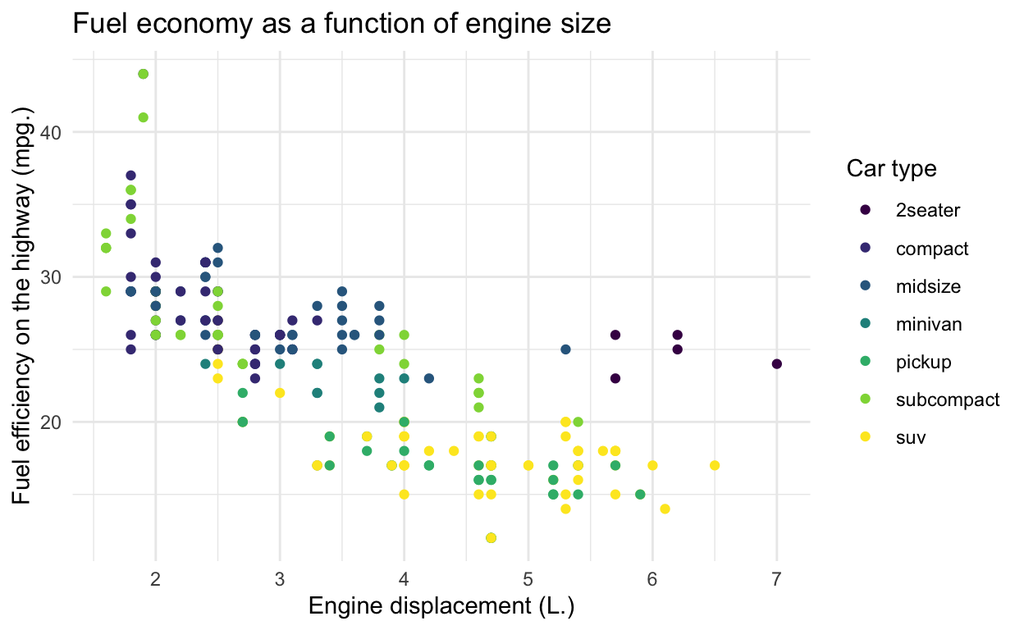

```r
mpg %>%
  ggplot(aes(displ, hwy, colour = class)) +
  geom_point() +
  theme_minimal() +
  scale_colour_viridis_d() +
  labs(
    title = "Fuel economy as a function of engine size",
    x = "Engine displacement (L.)",
    y = "Fuel efficiency on the highway (mpg.)",
    colour = "Car type"
  )
```

### 2.7. Saving plots

Do not use the built-in RStudio menu to save plots, as it will lower the resolution. Instead, use the `ggsave()` function, which saves the last plot generated by ggplot2. Read `?ggsave` to tailor your plots to the specification of a specific journal.

```r
mpg %>%
  ggplot(aes(displ, hwy)) +
  geom_point()
```

[output not shown]

```r
ggsave("output/plot.png")
```

## 3. Exercises

### 3.1. `diamonds` data set

For the exercises, we’ll use another data frame included with ggplot2.

```r
glimpse(diamonds)
```

```
Rows: 53,940
Columns: 10
$ carat   <dbl> 0.23, 0.21, 0.23, 0.29, 0.31, 0.24, 0.24, 0.26, 0.2…
$ cut     <ord> Ideal, Premium, Good, Premium, Good, Very Good, Ver…
$ color   <ord> E, E, E, I, J, J, I, H, E, H, J, J, F, J, E, E, I, …
$ clarity <ord> SI2, SI1, VS1, VS2, SI2, VVS2, VVS1, SI1, VS2, VS1,…
$ depth   <dbl> 61.5, 59.8, 56.9, 62.4, 63.3, 62.8, 62.3, 61.9, 65.…
$ table   <dbl> 55, 61, 65, 58, 58, 57, 57, 55, 61, 61, 55, 56, 61,…
$ price   <int> 326, 326, 327, 334, 335, 336, 336, 337, 337, 338, 3…
$ x       <dbl> 3.95, 3.89, 4.05, 4.20, 4.34, 3.94, 3.95, 4.07, 3.8…
$ y       <dbl> 3.98, 3.84, 4.07, 4.23, 4.35, 3.96, 3.98, 4.11, 3.7…
$ z       <dbl> 2.43, 2.31, 2.31, 2.63, 2.75, 2.48, 2.47, 2.53, 2.4…
```

### 3.2. Fill in the blanks

Fill in the blanks to reproduce the plot below:

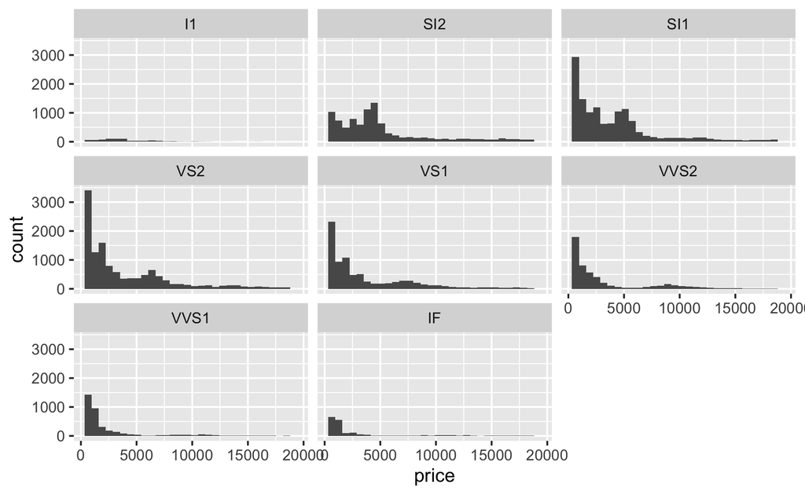

To check your results, run the code chunk below. Alternatively, to produce the plot in the `.html` output, remove the `eval = FALSE` argument from the code chunk.

```r
# Fill in the blanks
*** %>%
  ***(***(***)) +
  ***() +
  ***(~ ***)
```

### 3.3. Plot from scratch

Create the plot below from scratch:

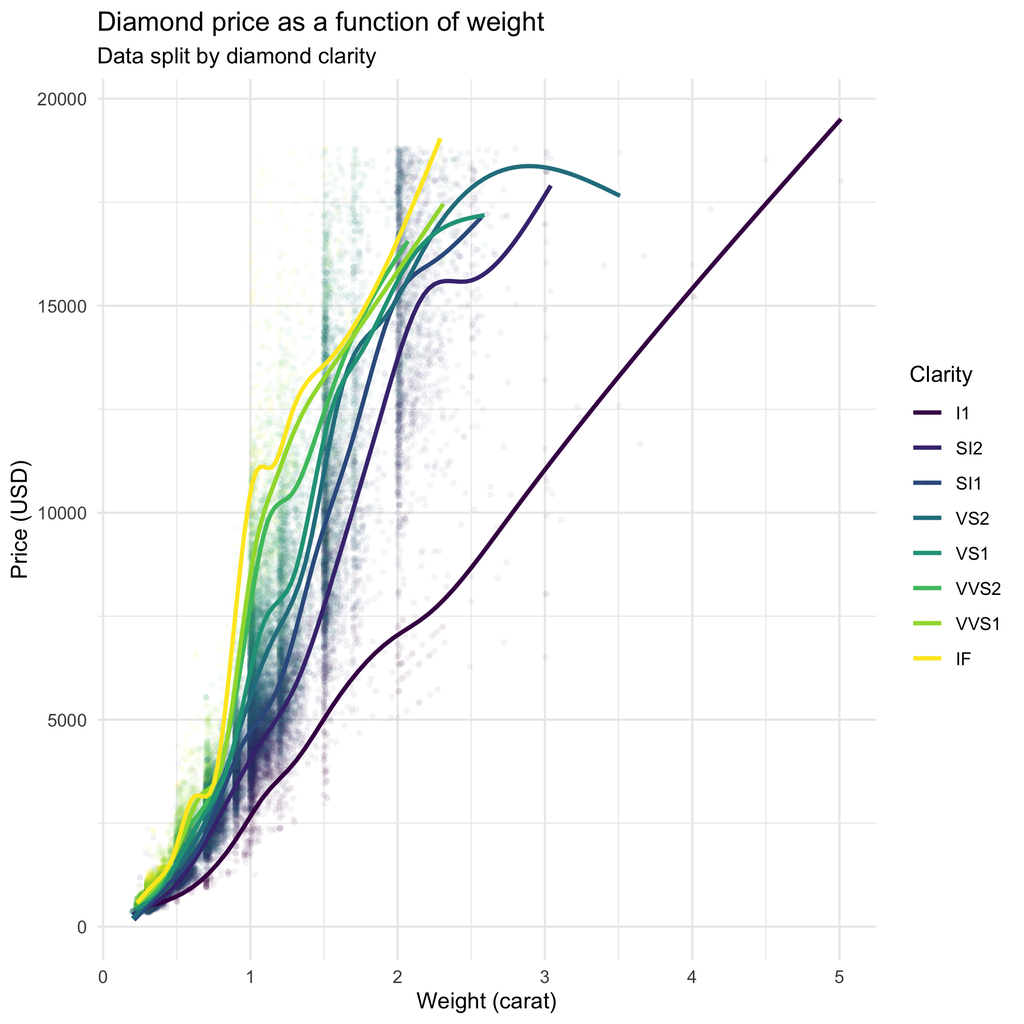

```r
# Create the plot here
```

## 4. Resources

- [ggplot2 reference](https://ggplot2.tidyverse.org/reference/index.html)
- [ggplot2 cheatsheet](https://github.com/rstudio/cheatsheets/blob/master/data-visualization-2.1.pdf)
- [ggplot2 book](https://ggplot2-book.org/)
- [R for Data Science book](https://r4ds.had.co.nz/)
- And most importantly, Google and Stack Overflow!